# VIQ - Laboratorio 5

2021-04-30

### Obiettivi

1. Usare ggplot per creare grafici

### Strumento

R ed RStudio, in particolare la libreria ggplot (parte di tidyverse):

### Dataset

Utilizziamo il dataset pubblico sui dati ISTAT con periodo di riferimento GENNAIO-FEBBRAIO 2021, pubblicati in data 06 APRILE 2021:

https://www.istat.it/it/archivio/256254

Usiamo il dataframe ripulito secondo le indicazioni dello scorso laboratorio. Il file `TidyIstat.R` contiene il codice per scaricare e ripulire i dati, che vengono salvati in `istat_occupazione.RDS` (formato compresso di R) che può essere letto tramite il metodo `read_rds()`.

```r
istat <- read_rds("istat_occupazione.RDS")
istat
```

| anno | mese | Sesso | data | attivita | occupazione | disoccupazione | disoccupazione.giovani |
| --- | --- | --- | --- | --- | --- | --- | --- |
| 2004 | Gennaio | MF | 2004-01-31 | 0.6251241 | 0.5726618 | 0.08318213 | 0.2302467 |
| 2004 | Gennaio | M | 2004-01-31 | 0.7423701 | 0.6949558 | 0.06325251 | NA |
| 2004 | Gennaio | F | 2004-01-31 | 0.5089549 | 0.4514910 | 0.11225915 | NA |
| 2004 | Febbraio | MF | 2004-02-29 | 0.6246365 | 0.5738719 | 0.08059644 | 0.2243787 |
| 2004 | Febbraio | M | 2004-02-29 | 0.7426258 | 0.6955450 | 0.06274963 | NA |
| 2004 | Febbraio | F | 2004-02-29 | 0.5077213 | 0.4533064 | 0.10669832 | NA |
| 2004 | Marzo | MF | 2004-03-31 | 0.6280778 | 0.5760631 | 0.08194947 | 0.2313517 |
| 2004 | Marzo | M | 2004-03-31 | 0.7463560 | 0.6973115 | 0.06492869 | NA |
| 2004 | Marzo | F | 2004-03-31 | 0.5108715 | 0.4559136 | 0.10680558 | NA |
| 2004 | Aprile | MF | 2004-04-30 | 0.6229403 | 0.5717253 | 0.08147783 | 0.2389849 |

[output cut: 608 more lines]

- Mostrare l’andamento del tasso di disosccupazione di Femmine, Maschi, e Generale.
  - Usare prima dei punti colorati in modo diverso:

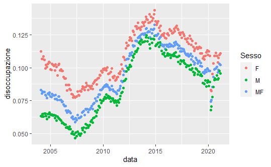

```r
## DA COMPLETARE
istat %>%
  ggplot(aes(x=data, y=disoccupazione, color=Sesso)) +
  geom_point()
```

- e poi usare delle linee:

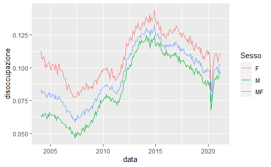

```r
## DA COMPLETARE
istat %>%
  ggplot(aes(x=data, y=disoccupazione, color=Sesso)) +
  geom_line()
```

- Riflessione: quale dei due tipi di layer è più adatto?

## Scale

La visualizzazione può essere personalizzata prima di tutto tramite delle opportune scale che fanno corrispondere i valori delle variabili a delle diverse caratteristiche visuali.

### Scala colore

- Modificare il diagramma a linee precedente in modo che i colori utilizzati per Donne, Uomini e Generale siano rispettivamente rosa, blu e grigio (`pink`,`skyblue`, `gray50`).

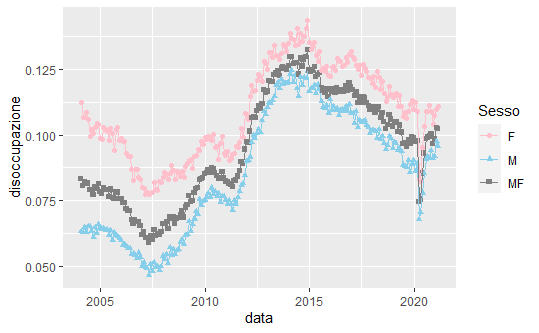

```r
## DA COMPLETARE
istat %>%
  ggplot(aes(x = data, y = disoccupazione, color = Sesso, shape = Sesso)) +
  geom_point() +
  geom_line() +
  scale_color_manual(values = c("pink", "skyblue", "gray50"))
```

### Altre scale

È possibile utilizzare delle scale per qualsiasi aspetto estetico, ad esempio per `geom_line()` è possibile specificare l’estetica `linetype` per il tipo di linea:

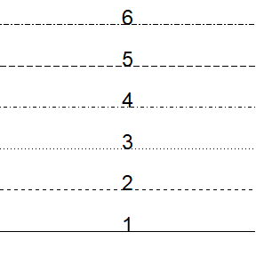

- Modificare il grafico del punto precedente in modo che i valori per Maschi e Femmine siano a tratto continuo, mentre quelli Generali siano a punto e linea.
  - Suggerimento: si utilizzi la funzione `scale_linetype_manual()`.

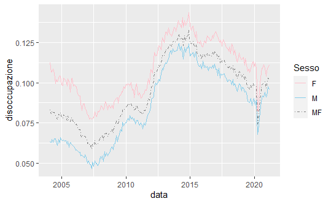

```r
## DA COMPLETARE
istat %>%
  ggplot(aes(x = data, y = disoccupazione, color = Sesso, linetype = Sesso)) +
  geom_line() +
  scale_linetype_manual(values = c(1, 1, 4)) +
  scale_color_manual(values = c("pink", "skyblue", "gray50"))
```

```r
NA
```

### Scala posizione

La scala verticale rappresenta dei tassi (<1) che potrebbero essere rappresentati meglio come percentuali. È possibile utilizzare la funzione `scale_y_continuous()` per specificare come stampare le etichette. In particolare è possibile utilizzare il parametro `labels` a cui passare una funzione che - prende i valori corrispondenti alle etichette - resituisce l’etichetta (ad es. 0.12 dovrebbe diventare “12%”)

- Modificare il grafico precedente in modo da stampare correttamente le percentuali sull’asse y.
  - Suggerimento: è possibile scrivere esplicitamente la funzione oppure usare `scales::percent` che è una funzione già definita.

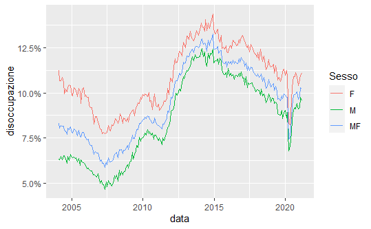

```r
## DA COMPLETARE
istat %>%
  ggplot(aes(x = data, y = disoccupazione, color = Sesso)) +
  geom_line() +
  scale_y_continuous(labels = scales::percent)
```

## Direct labeling

- Rimuovere la legenda e sostituirla con un direct labeling.
  - Suggerimento: per rimuovere la legenda legata ad una scale, usare `guide="none"` nella funzione di scala
  - Suggerimento: per allineare il testo alla destra dell’estremo destro delle linee, è possibile usare il parametro `hjust=0`, ed il parametro `nudge_x` per distanziarlo ulteriormente.

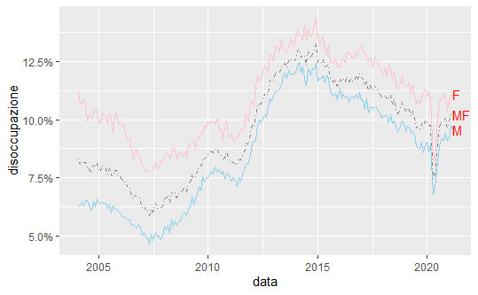

```r
## DA COMPLETARE
istat %>%
  ggplot(aes(x = data, y = disoccupazione, color = Sesso, linetype = Sesso)) +
  geom_line() +
  geom_text(aes(label = Sesso), data = subset(istat, data == tail(istat$data, n=1)), color = "red", hjust = 0) +
  scale_color_manual(values = c("pink", "skyblue", "gray50"), guide = "none") +
  scale_linetype_manual(values = c(1, 1, 4), guide = "none") +
  scale_y_continuous(labels = scales::percent)
```

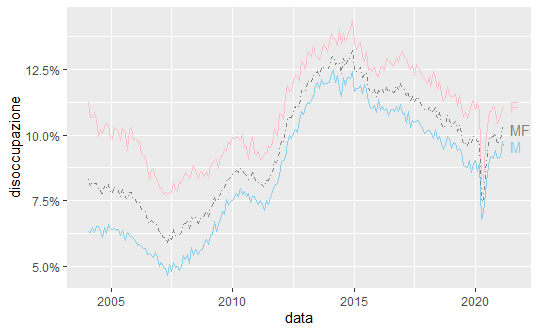

```r
estremo <- istat %>% filter(data == max(data))
istat %>%
  ggplot(aes(x = data, y = disoccupazione, color = Sesso, linetype = Sesso)) +
  geom_line() +
  scale_color_manual(values = c("pink", "skyblue", "gray50"), guide = "none") +
  scale_linetype_manual(values = c(1, 1, 4), guide = "none") +
  scale_y_continuous(breaks = c(0.05, 0.075, 0.1, 0.125), labels = scales::percent) +
  geom_text(aes(label = Sesso), data = estremo, hjust = 0, nudge_x = 100)
```

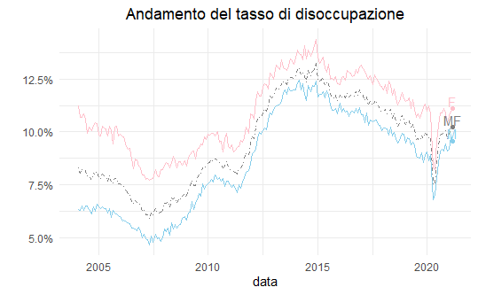

```r
istat %>%
  ggplot(aes(x = data, y = disoccupazione, color = Sesso, linetype = Sesso)) +
  geom_line() +
  scale_color_manual(values = c("pink", "skyblue", "gray50"), guide = "none") +
  scale_linetype_manual(values = c(1, 1, 4), guide = "none") +
  scale_y_continuous(breaks = c(0.05, 0.075, 0.1, 0.125), labels = scales::percent) +
  geom_point(data = estremo) +
  geom_text(aes(label = Sesso), data = estremo, hjust = "center", vjust = "bottom", nudge_y = 0.001) +
  ylab("") +
  ggtitle("Andamento del tasso di disoccupazione") +
  theme_minimal() +
  theme(plot.title = element_text(hjust = 0.5))
```

## Serie multiple

- Mostrare l’andamento del tasso di disoccupazione generale e quello giovanile
  - Suggerimento: per lasciare spazio sufficiente all’etichetta è possibile usare il parametro `expand` della funzione di scale che riceve il risultato della funzione `expansion()` (si veda Help per ulteriori indicazioni).

```r
## DA COMPLETARE
istat_long <- istat %>%  pivot_longer(cols = c("disoccupazione", "disoccupazione.giovani"), names_to = "type", values_to = "values") %>% filter(Sesso == "MF") %>% mutate(type = as.factor(type)) %>% mutate(type = fct_recode(type, generale = "disoccupazione", giovanile = "disoccupazione.giovani"))

istat_long
```

| anno | mese | Sesso | data | attivita | occupazione | type | values |
| --- | --- | --- | --- | --- | --- | --- | --- |
| 2004 | Gennaio | MF | 2004-01-31 | 0.6251241 | 0.5726618 | generale | 0.08318213 |
| 2004 | Gennaio | MF | 2004-01-31 | 0.6251241 | 0.5726618 | giovanile | 0.23024666 |
| 2004 | Febbraio | MF | 2004-02-29 | 0.6246365 | 0.5738719 | generale | 0.08059644 |
| 2004 | Febbraio | MF | 2004-02-29 | 0.6246365 | 0.5738719 | giovanile | 0.22437874 |
| 2004 | Marzo | MF | 2004-03-31 | 0.6280778 | 0.5760631 | generale | 0.08194947 |
| 2004 | Marzo | MF | 2004-03-31 | 0.6280778 | 0.5760631 | giovanile | 0.23135172 |
| 2004 | Aprile | MF | 2004-04-30 | 0.6229403 | 0.5717253 | generale | 0.08147783 |
| 2004 | Aprile | MF | 2004-04-30 | 0.6229403 | 0.5717253 | giovanile | 0.23898487 |
| 2004 | Maggio | MF | 2004-05-31 | 0.6275064 | 0.5756755 | generale | 0.08166989 |
| 2004 | Maggio | MF | 2004-05-31 | 0.6275064 | 0.5756755 | giovanile | 0.23997998 |

[output cut: 402 more lines]

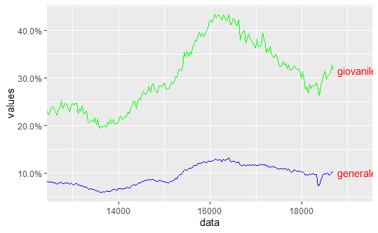

```r
istat_long %>%
  ggplot(aes(x=data, y=values, color = type)) +
  geom_line() +
  geom_text(aes(label = type), data = subset(istat_long, data == tail(istat$data, n=1)), color = "red", hjust = 0, nudge_x=100) +
  scale_y_continuous(labels = scales::percent) +
  #scale_x_continuous(expand = expansion(mult = c(0, .35))) +
  scale_x_continuous(expand = expansion(mult = c(0, .12))) +
  scale_color_manual(values = c("blue", "green"), guide = "none")
```

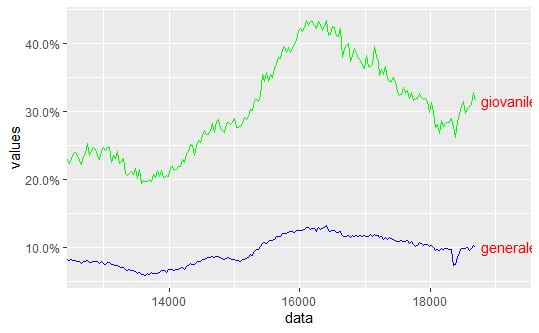

```r
istat_right <- istat_long %>% filter(data == max(data))

istat_long %>%
  ggplot(aes(x=data, y=values, color = type)) +
  geom_line() +
  geom_text(aes(label = type), data = istat_right, color = "red", hjust = 0, nudge_x=100) +
  scale_y_continuous(labels = scales::percent) +
  #scale_x_continuous(expand = expansion(mult = c(0, .35))) +
  scale_x_continuous(expand = expansion(mult = c(0, .12))) +
  scale_color_manual(values = c("blue", "green"), guide = "none")
```

## Annotazioni

- Modificare il grafico precedente in modo da mostrare il valore massimo, il valore minimo ed il valore finale (assieme alla *direct label*) di ciascuna serie.

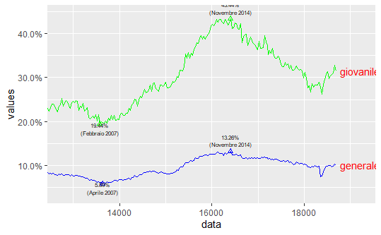

```r
## DA COMPLETARE
max_d <- istat_long %>% group_by(type) %>% filter(values == max(values))
min_d <- istat_long %>% group_by(type) %>% filter(values == min(values))

istat_long %>%
  ggplot(aes(x=data, y=values, color = type)) +
  geom_line() +
  geom_text(aes(label = type), data = istat_right, color = "red", hjust = 0, nudge_x=100) +
  scale_y_continuous(labels = scales::percent) +
  scale_x_continuous(expand = expansion(mult = c(0, .12))) +
  scale_color_manual(values = c("blue", "green"), guide = "none") +

  geom_point(data = max_d, shape = 2) +
  geom_text(aes(label = paste0(round(values*100,2),"%\n(", mese, " ", anno, ")")), data = max_d, colour = "black", vjust = 0, hjust = 0.5, nudge_y = 0.01, size = 2) +

  geom_point(data = min_d, shape = 2) +
  geom_text(aes(label = paste0(round(values*100,2),"%\n(", mese, " ", anno, ")")), data = min_d, colour = "black", vjust = "bottom", hjust = 0.5, nudge_y = -0.025, size = 2)
```

```r
NA
```

## Aprossimazioni

- Scrivere una funzione che dato un vettore `v` di numeri ed un intero `n`, produca un vettore (di pari lunghezza) contenente la media mobile su `n` elementi. Visto che la media mobile non è definita per i primi $n/2$ elementi, il risultato deve contenere $\lfloor{(n-1)/2}\rfloor$ valori `NA` in testa e $\lfloor{n/2}\rfloor$ `NA` in coda.

| **v** | 2 | 5 | 2 | 6 | 6 | 6 | 3 | 4 | 1 | 6 |
| --- | --- | --- | --- | --- | --- | --- | --- | --- | --- | --- |
| **media mobile** | NA | 3 | 4.333 | 4.667 | 6 | 5 | 4.333 | 2.667 | 3.667 | NA |

```r
## DA COMPLETARE
media_mobile <- function(v, n){
  sum <- 0
  med <- 0
  nn <- floor(n/2)
  for (i in 1:length(v)){
    if(i <= nn | i > (length(v) - nn)){
      med[i] <- NA
    }
    else{
      sum <- 0
      for (j in 0:(n-1)){
        sum <- sum + v[i - nn + j]
      }
      med[i] <- sum/n
    }
  }
  return (med)
}
```

```r
vector <- c(2,5,2,6,6,6,3,4,1,6)
print (media_mobile(vector, 3))
```

```
 [1]       NA 3.000000 4.333333 4.666667 6.000000 5.000000
 [7] 4.333333 2.666667 3.666667       NA
```

- Rappresentare l’andamento della disoccupazione giovanile con aggiunta la media mobile a tre mesi.

```r
## DA COMPLETARE
istat_med_mob <- istat %>% filter(Sesso == "MF")
istat_med_mob$med_mob <- media_mobile(istat_med_mob$disoccupazione.giovani, 3)

istat_med_mob
```

| anno | mese | Sesso | data | attivita | occupazione | disoccupazione | disoccupazione.giovani | med_mob |
| --- | --- | --- | --- | --- | --- | --- | --- | --- |
| 2004 | Gennaio | MF | 2004-01-31 | 0.6251241 | 0.5726618 | 0.08318213 | 0.2302467 | NA |
| 2004 | Febbraio | MF | 2004-02-29 | 0.6246365 | 0.5738719 | 0.08059644 | 0.2243787 | 0.2286590 |
| 2004 | Marzo | MF | 2004-03-31 | 0.6280778 | 0.5760631 | 0.08194947 | 0.2313517 | 0.2315718 |
| 2004 | Aprile | MF | 2004-04-30 | 0.6229403 | 0.5717253 | 0.08147783 | 0.2389849 | 0.2367722 |
| 2004 | Maggio | MF | 2004-05-31 | 0.6275064 | 0.5756755 | 0.08166989 | 0.2399800 | 0.2378884 |
| 2004 | Giugno | MF | 2004-06-30 | 0.6278453 | 0.5777809 | 0.07910018 | 0.2347004 | 0.2344037 |
| 2004 | Luglio | MF | 2004-07-31 | 0.6267282 | 0.5767071 | 0.07898022 | 0.2285308 | 0.2286365 |
| 2004 | Agosto | MF | 2004-08-31 | 0.6233057 | 0.5748012 | 0.07711563 | 0.2226782 | 0.2284453 |
| 2004 | Settembre | MF | 2004-09-30 | 0.6256192 | 0.5749860 | 0.08027493 | 0.2341267 | 0.2317851 |
| 2004 | Ottobre | MF | 2004-10-31 | 0.6266529 | 0.5763153 | 0.07949990 | 0.2385504 | 0.2419086 |

[output cut: 196 more lines]

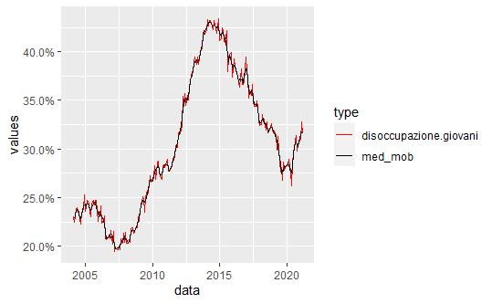

```r
istat_med_mob %>%
  pivot_longer(cols = c("disoccupazione.giovani", "med_mob"), names_to = "type", values_to = "values") %>%
  ggplot(aes(x = data, y = values, color = type)) +
  geom_line() +
  scale_color_manual(values = c("red", "black")) +
  scale_y_continuous(labels = scales::percent)
```

```r
NA
```

- Rappresentare l’andamento della disoccupazione giovanile con aggiunta l’interpolazione LOESS, tramite la funzione `geom_smooth()`.

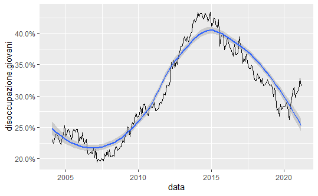

```r
## DA COMPLETARE
istat %>%
  filter(Sesso == "MF") %>%
  ggplot(aes(x = data, y = disoccupazione.giovani)) +
  geom_line() +
  scale_y_continuous(labels = scales::percent) +
  geom_smooth(method = loess, formula = y ~ x)
```

## Valori derivati

Dalla [nota metodologica ISTAT](https://www.istat.it/it/files//2021/04/CS_Occupati_disoccupati_FEBBRAIO_2021.pdf) sappiamo che

- Occupati: persone (15-89 anni) che hanno lavorato o sono in permesso
- Disoccupati: persone (15-74 anni) che sono in cerca di lavoro
- Popolazione: persone nella fascia d’età considerata
- Attivi: Occupati + Disoccupati

Il tasso di attività è dato da:

$$t_A = \frac{Attivi}{Popolazione}$$

Il tasso di occupazione è dato da:

$$t_O = \frac{Occupati}{Popolazione}$$

Il tasso di disoccupazione è dato da:

$$t_D = \frac{Disoccupati}{Attivi}$$

A partire dai valori precedenti definiti e forniti dall’ISTAT quindi possiamo calcolare:

La proporzione di disoccupati sulla popolazione totale:

$$p_D = \frac{Disoccupati}{Popolazione} = t_D \cdot t_A$$

La proporzione di inattivi (non attivi) sulla popolazione totale.

$$p_I = \frac{Inattivi}{Popolazione} = 1 - t_A$$

Le proporzione di riferimento per Occupati e Disoccupati non sono esattamente le stesse, ma la differenza è minima, perciò abbiamo:

$$p_D + t_O + p_I \approx 1$$

- Verificare che la distribuzione della somma tra Tasso di Occupazione, Proporzione di Disoccupati e Proporzione Inattivi sia circa 1 (usando un boxplot) per M, F e MF.

```r
## DA COMPLETARE
calcolo_somma <- function(ta, to, td){
  pd <- td*ta
  pi <- 1-ta
  return (pd + to + pi)
}
```

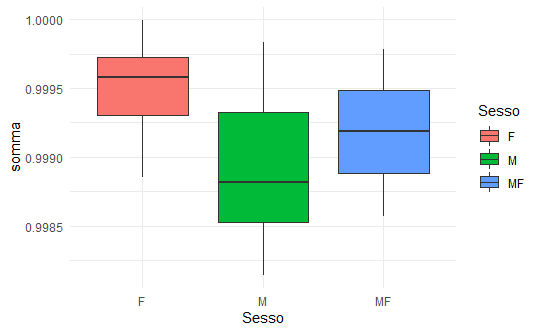

```r
istat$somma <- calcolo_somma(istat$attivita, istat$occupazione, istat$disoccupazione)
istat %>%
  ggplot(aes(x = Sesso, y = somma, fill = Sesso)) +
  geom_boxplot() +
  theme_minimal()
```

**Riflessione** lo scostamento è dovuto alla non esatta corrispondenza tra le popolazioni, in particolare è tanto più ampio quando più c’è una parte di occupati nella popolazione tra 74 e 89 anni.

- Modificare il diagramma precedente usando un violin plot sopra il quale riportare i punti relativi ai singoli valori.
  - usare il parametro `position="jitter"` per sparpagliare in maniera casuale i punti, evitando così di averli tutti allineati e sovrapposti.

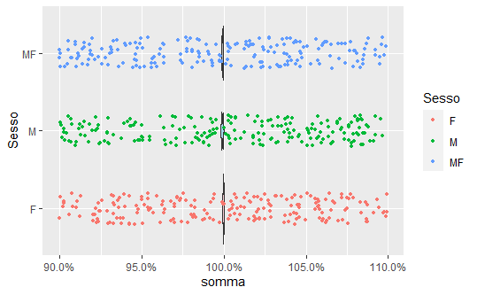

```r
## DA COMPLETARE
istat %>%
  ggplot(aes(x = somma, y = Sesso, fill = Sesso)) +
  geom_violin(alpha = 0.7) +
  scale_fill_manual(values = c("pink", "skyblue", "grey60"), guide = "none") +
  geom_point(aes(colour = Sesso), position = position_jitter(width = 0.1, height = 0.2), size = 1) +
  scale_x_continuous(labels = scales::percent)
```

- Mostrare con un diagramma ad area l’andamento delle tre componenti della somma nel corso del periodo di osservazione per la popolazione generale (MF).

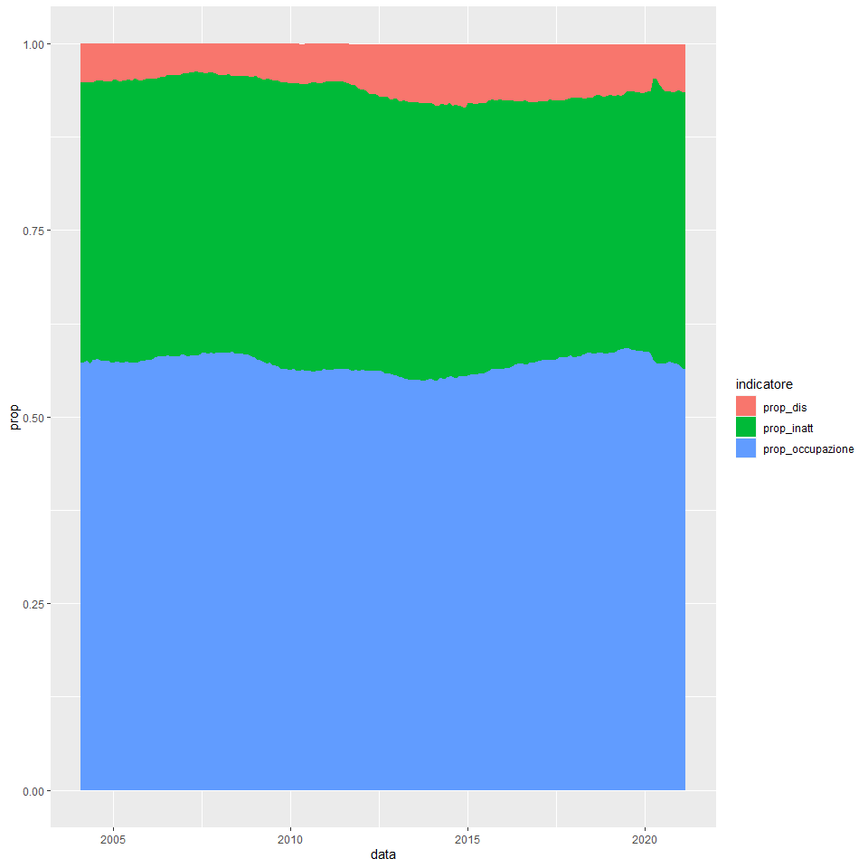

```r
## DA COMPLETARE
istat$prop_dis <- istat$attivita*istat$disoccupazione
istat$prop_inatt <- 1 - istat$attivita
colnames(istat)[colnames(istat) == "occupazione"] <- "prop_occupazione"

istat %>%
  filter(Sesso == "MF") %>%
  select(data, Sesso, starts_with("prop_")) %>%
  pivot_longer(starts_with("prop_"), names_to = "indicatore", values_to = "prop") %>%
  mutate(indicatore = as.factor(indicatore)) %>%
  ggplot(aes(x = data, y = prop, fill = indicatore)) +
  geom_area()
```